# Arctic Sea Ice Extent Forecast

Denis Willett

August 24, 2014

```r
library(TTR)
library(ggplot2)
library(lubridate)
library(reshape2)
library(dplyr)
library(pander)
library(forecast)
library(gridExtra)
library(FNN)
```

## Question (from GJP):

**#1414** On 15 September 2014, will the Arctic sea ice extent be less than that of 15 September 2013?

### Interpretaion Clarifications (from GJP):

The sea ice extent is the total surface area of the Arctic under ice cover; a lower sea ice extent makes shipping and fishing in the region more feasible. In recent years, mid-September has marked the point at which Arctic sea ice extent has decreased to its lowest point, after which the freeze begins again. On 15 September 2013, the Arctic sea ice extent was 4,834,931 square kilometers (km2). Outcome will be determined on 15 September 2014 by the Japan Aerospace Exploration Agency’s Arctic Sea Ice Monitor, at http://www.ijis.iarc.uaf.edu/en/home/seaice_extent.htm . For historical trends, click “data download” and save as a csv file. If the resolution criteria are not met, GJP will assume the following as the “status quo” outcome: Arctic sea ice extent on 15 September 2014 will not be less than 4,834,931 square kilometers.

### Initial Assessment:

Date: August 23rd, 2014

### Schedule:

Due: September 15th, 2014

Milestones: 22 days left. Revisit on a weekly basis to double check assumptions and models.

# CHAMPS-KNOW Analysis

## Comparison Classes (Base Rates):

The closest comparable base rate would likely be the number of times sea ice extent has been below the benchmark over the last decade. See Table One below for that information.

Other comparisons could involve examining the relationship between warming and sea ice extent, but that information should already be embodied in the sea ice extent data (see [Whitney’s theorem](http://en.wikipedia.org/wiki/Whitney%27s_embedding_theorem) about embedding dimensions).

## Hunt for Right Information:

Because the question will be decided by reporting from Japanese Aerospace Exploration Agency [JAXA](http://www.ijis.iarc.uaf.edu/en/home/seaice_extent.htm), their data will be primarily used in this analysis.

Data were available from two sources:

- The arctic sea ice monitor page ([here](http://www.ijis.iarc.uaf.edu/seaice/extent/plot_v2.csv)) which had data from 2003 until the present (8/22/2014)
- Long term sea ice monitoring page ([here](http://kuroshio.eorc.jaxa.jp/JASMES/climate/index.html)) which required registration to access data from 1978 until 2013.

There were slight discrepancies between the data sets likely due to differences in calculating sea ice extent. To accomadate such discrepances, the historical dataset was paired with the more recent data set by combining data from 1978-2003 from the long term sea ice monitoring page with data from 2003-present from the arctic sea ice monitor page.

This analysis rests primarily on statistical projections using various techniques. A brief intro to ARIMAs can be found [here](http://people.duke.edu/~rnau/411arim.htm) and [here](http://en.wikipedia.org/wiki/Autoregressive_integrated_moving_average). For information on state space reconstruction techniques, consult the work of [Floris Takens](http://en.wikipedia.org/wiki/Takens'_theorem) and [George Sugihara](http://deepeco.ucsd.edu/simplex/)

## Adjust and Update Information:

The models below can be updated on a weekly basis with more information from satellite data, but should be pretty robust to changes and should give a pretty good estimate even without new forthcoming data.

## Modeling

The modeling approach is three-fold and consists of:

- Visual inspection of trends in historical data
- Autoregressive integrated moving average (ARIMA) models
- Model-free state space reconstruction (SSR) techniques (namely simplex projection) that can perform better than model based techniques [1](http://www.pnas.org/content/early/2013/02/22/1216076110)

All modeling was done in R (this document was written in RMarkDown - thanks RStudio!!) and can be found [here](http://deniswillett.github.io/GJP/SeaIceCode.html)

### Visual Inspection

It is always helpful to visualize the data and examine trends in reference to the benchmark.

```r
earlydata <- read.table("seaicejaxa1.txt")
names(earlydata) <- c("Month", "Day", "Year", "Extent")

earlydata <- earlydata %>% mutate(Date = ymd(paste(Year, Month, Day, sep = "/"))) %>%
    filter(Year < 2003)

newdata <- read.csv("JAXA_Sea_Ice.csv") %>% melt(., id = c("Month", "Day"),
    variable.name = "Year", value.name = "Extent") %>% mutate(Year = as.numeric(substr(Year,
    2, 5)), Date = ymd(paste(Year, Month, Day, sep = "/")))

full.data <- rbind(earlydata, newdata)

full.data[which(full.data$Extent == -9999), 4] <- NA

full.data <- na.omit(full.data)

sept2013 <- 4834931
```

> **Figure 1:** Arctic Sea Ice Extent (in km<sup>2</sup>) from 1978 until the present (22nd of August, 2014). Green line denotes Arctic Sea Ice Extent on September 15, 2013. Blue line represents a smoothed trend from a generalized additive model.

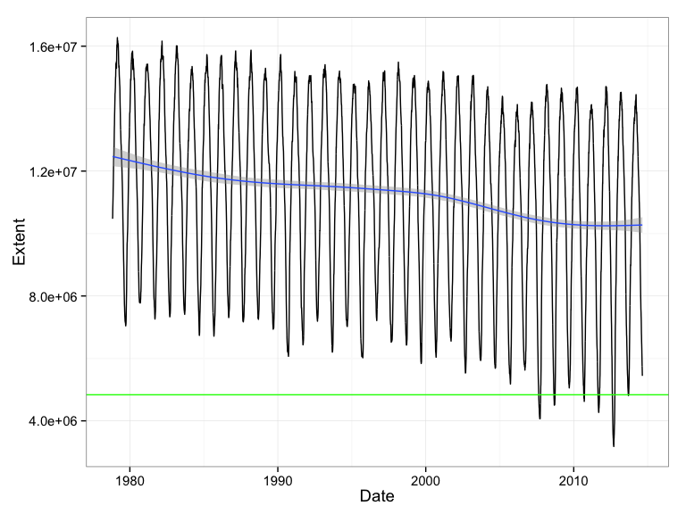

```r
ggplot(full.data, aes(x = Date, y = Extent)) + geom_line() + geom_hline(yintercept = sept2013,
    color = "green") + theme_bw(14) + stat_smooth()
```

Many news articles from the Google newsfeed report experts bemoaning declining sea ice trends. Lets see if this is indeed the case.

> **Figure 2:** Time series decomposition of Arctic Sea Ice Extent into a trend, seasonal, and random components. While there is a strong seasonal component, sea ice extent has exhibited a downward trend since 1978.

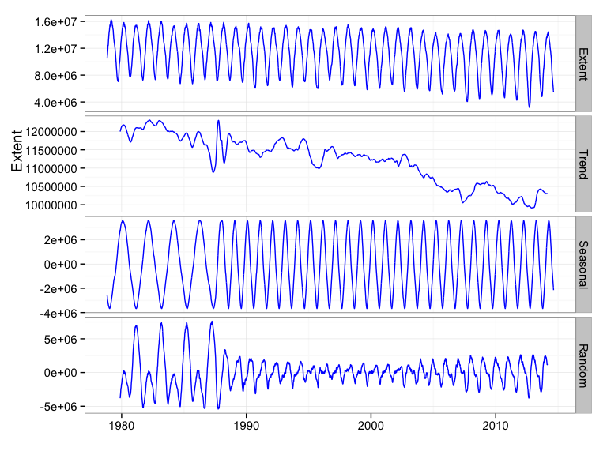

```r
dec <- decompose(ts(na.omit(full.data$Extent), frequency = 365))

p.ts <- data.frame(Date = full.data$Date, Extent = as.numeric(dec$x), Trend = as.numeric(dec$trend),
    Seasonal = as.numeric(dec$seasonal), Random = as.numeric(dec$random))

m.p.ts <- melt(p.ts, id = "Date", variable.name = "Type", value.name = "n")


ggplot(m.p.ts, aes(x = Date, y = n)) + geom_line(color = "blue") + theme_bw(14) +
    facet_grid(Type ~ ., scales = "free") + labs(x = "", y = "                               Extent")
```

How many times in the past decade or so has sea ice extent been less than that on September 15th of last year (see bolded rows below)?

```r
recentsept <- full.data %>% filter(Year >= 2000, Month == 9, Day == 15)
emphasize.strong.rows(which(recentsept$Extent <= sept2013))
pander(recentsept, caption = "Sea Ice Extent on September 15th of every year since 2000.")
```

Sea Ice Extent on September 15th of every year since 2000.

| Month | Day | Year | Extent | Date |
| --- | --- | --- | --- | --- |
| 9 | 15 | 2000 | 6109901 | 2000-09-15 |
| 9 | 15 | 2001 | 6575597 | 2001-09-15 |
| 9 | 15 | 2003 | 5937087 | 2003-09-15 |
| 9 | 15 | 2004 | 5811644 | 2004-09-15 |
| 9 | 15 | 2005 | 5329353 | 2005-09-15 |
| 9 | 15 | 2006 | 5634616 | 2006-09-15 |
| **9** | **15** | **2007** | **4068688** | **2007-09-15** |
| **9** | **15** | **2008** | **4523624** | **2008-09-15** |
| 9 | 15 | 2009 | 5115751 | 2009-09-15 |
| **9** | **15** | **2010** | **4743880** | **2010-09-15** |
| **9** | **15** | **2011** | **4442510** | **2011-09-15** |
| **9** | **15** | **2012** | **3178400** | **2012-09-15** |
| **9** | **15** | **2013** | **4834931** | **2013-09-15** |

### ARIMA Modeling

Autoregressive integrated moving average (ARIMA) models use a combination of moving average models which smooth over a given time span by averaging and autoregressive models which regress a time series against itself (with lags) to produce reasonably good forecasts (usually) of stationary time series.

```r
arima.model <- full.data$Extent %>% ts(., frequency = 365) %>% auto.arima(.,
    ic = "bic")

pred.arima <- as.data.frame(forecast(arima.model, h = 32))

dates <- seq(ymd("2014/8/23"), ymd("2014/9/23"), by = "days")

arima.pred <- data.frame(Date = dates, pred.arima)
```

> **Figure 3:** Sea Ice Extent forecast with an autoregressive integrated moving average model ARIMA(3,1,1) selected using Bayesian information criteria. Black line denotes historical data. Blue line denotes forecast. Dark grey shading indicates 80% confidence intervals. Light grey shading indicates 95% confidence intervals. Green line indicates sea ice extent on September 15, 2013.

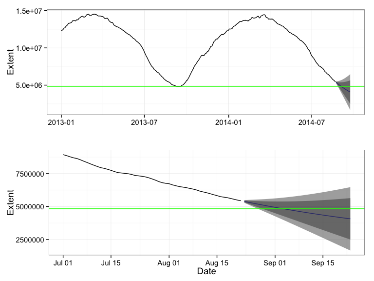

```r
large.plot <- ggplot() + geom_line(data = subset(full.data, Year >= 2013), aes(x = Date,
    y = Extent)) + geom_line(data = arima.pred, aes(x = Date, y = Point.Forecast),
    color = "blue") + geom_ribbon(data = arima.pred, aes(x = Date, ymax = Hi.80,
    ymin = Lo.80), fill = "grey20", alpha = 0.5) + geom_ribbon(data = arima.pred,
    aes(x = Date, ymax = Hi.95, ymin = Lo.95), fill = "grey30", alpha = 0.5) +
    geom_hline(yintercept = sept2013, color = "green") + theme_bw(14) + labs(x = "")

small.plot <- ggplot() + geom_line(data = subset(full.data, Date >= ymd("2014-07-01")),
    aes(x = Date, y = Extent)) + geom_line(data = arima.pred, aes(x = Date,
    y = Point.Forecast), color = "blue") + geom_ribbon(data = arima.pred, aes(x = Date,
    ymax = Hi.80, ymin = Lo.80), fill = "grey20", alpha = 0.5) + geom_ribbon(data = arima.pred,
    aes(x = Date, ymax = Hi.95, ymin = Lo.95), fill = "grey30", alpha = 0.5) +
    geom_hline(yintercept = sept2013, color = "green") + theme_bw(14)

grid.arrange(large.plot, small.plot, ncol = 1)
```

```r
arima.pred %>% filter(Date == ymd("2014-09-15")) %>% pander(., caption = "Projected Sea Ice Extent on September 15, 2014")
```

Projected Sea Ice Extent on September 15, 2014

| Date | Point.Forecast | Lo.80 | Hi.80 | Lo.95 | Hi.95 |
| --- | --- | --- | --- | --- | --- |
| 2014-09-15 | 4354029 | 3220443 | 5487614 | 2620360 | 6087698 |

### Simplex Projection

Simplex projection is a state space reconstruction technique that provides model free forecasts of time series. A great overview of simplex projection can be found [here](http://deepeco.ucsd.edu/simplex/) and a comparision with other forecasting methods can be found [here](http://www.pnas.org/content/early/2013/02/22/1216076110).

```r
# Establish Embedding Function
Embed <- function(x, m, d = 1, indices = FALSE, as.embed = TRUE) {
    n <- length(x) - (m - 1) * d
    X <- seq_along(x)
    if (n <= 0)
        stop("Insufficient observations for the requested embedding")
    out <- matrix(rep(X[seq_len(n)], m), ncol = m)
    out[, -1] <- out[, -1, drop = FALSE] + rep(seq_len(m - 1) * d, each = nrow(out))
    if (as.embed)
        out <- out[, rev(seq_len(ncol(out)))]
    if (!indices)
        out <- matrix(x[out], ncol = m)
    out
}

dSimplex = function(dta, eDim, tLag, tao, Embed) {
    k = eDim + 2

    # Embed
    embDta = Embed(dta, eDim, tLag)

    # Get k nearest neighbors
    nn = get.knnx(embDta, embDta, k = k)

    # Get value of interest (last value)
    ind = nn$nn.index[nrow(nn$nn.index), 2:k]

    dist = nn$nn.dist[nrow(nn$nn.dist), 2:k]

    # Advance to predicted time step by tao
    ind = ind + tao

    # Calculate ui for weights
    ui = exp(-dist/min(dist))

    # Calculate sumuj
    sumuj = sum(ui)

    # Get values to project
    values = embDta[ind, eDim]

    # Projected value
    proj = sum(ui * values/sumuj)


    # Return Projected Value
    return(proj)
}
```

The first step in simplex dimension is choosing the appropriate embedding dimension (that which produces the highest predictive power) by examining correlations between predictions of historical data and the historical data itself.

> **Figure 4:** Selection of embedding dimension prior to simplex dimension. An embedding dimension of two produces the highest correlation between predictions and actual values.

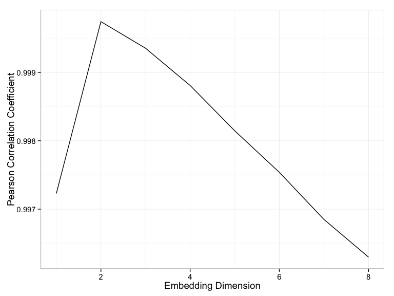

```r
test <- full.data %>% filter(Date >= ymd("2014-07-01"))

train <- full.data %>% filter(Date < ymd("2014-07-01"))

cors <- numeric(8)
for (j in 1:8) {
    proj <- numeric(53)
    for (i in 0:52) {
        simplexdata = c(train$Extent, test$Extent[0:i])
        proj[i + 1] <- dSimplex(dta = simplexdata, eDim = j, tLag = 1, tao = 1,
            Embed = Embed)
    }

    compare <- data.frame(Proj = proj, Test = test$Extent)
    compare <- na.omit(compare)
    cors[j] <- cor(compare$Proj, compare$Test)
}

eDims <- data.frame(eDim = 1:8, Cors = cors)

ggplot(eDims, aes(x = eDim, y = Cors)) + geom_line() + theme_bw(14) + labs(x = "Embedding Dimension",
    y = "Pearson Correlation Coefficient")
```

> **Figure 5:** Forecasts from Simplex Projection. Black line denotes historical data. Blue line indicates projected sea ice extent. Green line indicates sea ice extent on September 15, 2013.

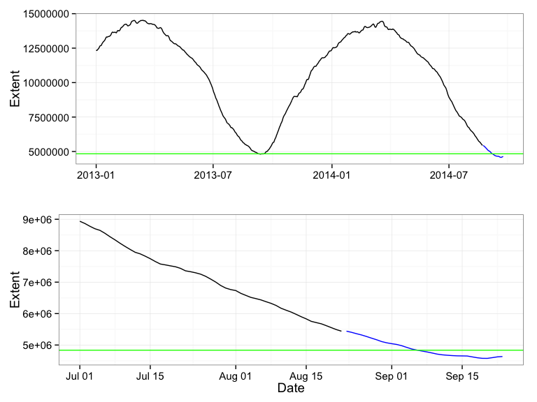

```r
simplexproj = numeric(32)
for (i in 1:32) {
    simplexproj[i] <- dSimplex(dta = full.data$Extent, eDim = 2, tLag = 1, tao = i,
        Embed = Embed)
}

simplex.pred <- data.frame(Date = dates, Pred = simplexproj)

large.plot <- ggplot() + geom_line(data = subset(full.data, Year >= 2013), aes(x = Date,
    y = Extent)) + geom_line(data = simplex.pred, aes(x = Date, y = Pred), color = "blue") +
    geom_hline(yintercept = sept2013, color = "green") + theme_bw(14) + labs(x = "")

small.plot <- ggplot() + geom_line(data = subset(full.data, Date >= ymd("2014-07-01")),
    aes(x = Date, y = Extent)) + geom_line(data = simplex.pred, aes(x = Date,
    y = Pred), color = "blue") + geom_hline(yintercept = sept2013, color = "green") +
    theme_bw(14)

grid.arrange(large.plot, small.plot, ncol = 1)
```

```r
names(simplex.pred) = c("Date", "Projected Sea Ice Extent")
simplex.pred %>% filter(Date == ymd("2014-09-15")) %>% pander(., caption = "Projected Sea Ice Extent (km^2) on September 15, 2014")
```

Projected Sea Ice Extent (km^2) on September 15, 2014

| Date | Projected Sea Ice Extent |
| --- | --- |
| 2014-09-15 | 4653597 |

## Post Mortem Analysis

Not yet…

## Select the right level of effort.

Question is understandable, information is accessible, and personal background makes this intriguing (time series analysis is fun!).

## Power players and preferences

Relevant players are humans and the japanese monitoring agency. Preferences should ideally not come into play as the outcome of the question is based on empirical data.

## Norms, Rules, Protocols

It seems the only relevant norms, rules or protocols for this question revolve around reporting method and calculating sea ice extent. The agency has changed calculation methods in the past, but unless they change them again prior to the 15th, this facet should not have a large impact on the outcomes.

## Other Perspectives

It seems most news sources (from a simple google search) cite warming trends, waves, etc as leading to record declines in sea ice extent, but few contain any data whatsoever. That being said, not one article (from a cursory search) seems to offer that this year could be anything other than a record low for sea ice extent.

## Wildcards

Not likely, but then they never are…

# Forecast

This forecast is based almost entirely off of modeling.

Based on:

- visual inspection of historical trends (6 out of the past 7 years have had sea ice extent less than (or at) the extent found on September 15, 2013)
- ARIMA models (the projected value and ~ 70% of the confidence bands are below the benchmark)
- Simplex projection (the projected value is less than the benchmark)

I am going to assign an initial 85% probability to the outcome that sea ice extent will be less than 4.8349 × 10<sup>6</sup>km<sup>2</sup> on September 15, 2014 to be updated (probably upward) in the coming weeks.

### Exploratory Data Analysis

```r
earlydata <- read.table("seaicejaxa1.txt")
names(earlydata) <- c("Month", "Day", "Year", "Extent")

newdata <- read.csv("JAXA_Sea_Ice_2014.csv")
names(newdata)[3] <- "2014"
m.newdata <- melt(newdata, id = c("Month", "Day"), variable.name = "Year", value.name = "Extent") %>%
    mutate(Year = as.numeric(2014))
red.earlydata <- earlydata %>% filter(Year != 2014)

full.data <- rbind(red.earlydata, m.newdata)

full.data[which(full.data$Extent == -9999), 4] <- NA

sept2013 <- 4834931

mod.data <- full.data %>% na.omit(.) %>% mutate(Date = ymd(paste(Year, Month,
    Day, sep = "/")))
```

Time Series:

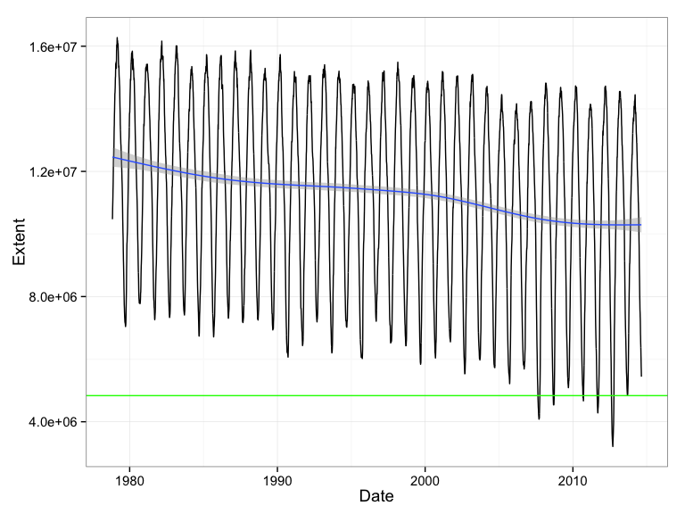

```r
ggplot(mod.data, aes(x = Date, y = Extent)) + geom_line() + geom_hline(yintercept = sept2013,
    color = "green") + theme_bw(14) + stat_smooth()
```

Time Series Decomposition:

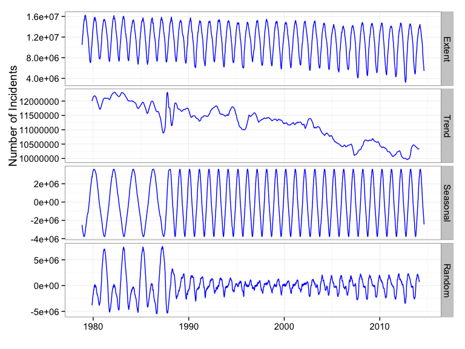

```r
dec <- decompose(ts(na.omit(full.data$Extent), frequency = 365))

p.ts <- data.frame(Date = mod.data$Date, Extent = as.numeric(dec$x), Trend = as.numeric(dec$trend),
    Seasonal = as.numeric(dec$seasonal), Random = as.numeric(dec$random))

m.p.ts <- melt(p.ts, id = "Date", variable.name = "Type", value.name = "n")

ggplot(m.p.ts, aes(x = Date, y = n)) + geom_line(color = "blue") + theme_bw(14) +
    facet_grid(Type ~ ., scales = "free") + labs(x = "", y = "                               Number of Incidents")
```

Mins, maxes, and means:

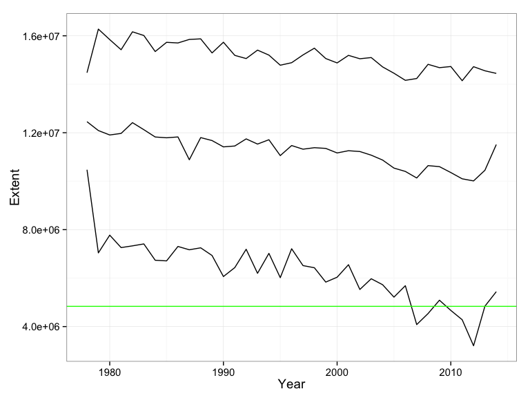

```r
mod.data %>% group_by(Year) %>% summarize(min = min(Extent), max = max(Extent),
    mn = mean(Extent)) %>% melt(., id = "Year", value.name = "Extent", variable.name = "Type") %>%
    ggplot(., aes(x = Year, y = Extent, group = Type)) + geom_line() + theme_bw(14) +
    geom_hline(yintercept = sept2013, color = "green")
```

```r
mod.data %>% filter(Year >= 2000, Month == 9, Day == 15)
```

```
##    Month Day Year  Extent       Date
## 1      9  15 2000 6109901 2000-09-15
## 2      9  15 2001 6575597 2001-09-15
## 3      9  15 2003 5997862 2003-09-15
## 4      9  15 2004 5796072 2004-09-15
## 5      9  15 2005 5354323 2005-09-15
## 6      9  15 2006 5700336 2006-09-15
## 7      9  15 2007 4096845 2007-09-15
## 8      9  15 2008 4537465 2008-09-15
## 9      9  15 2009 5143420 2009-09-15
## 10     9  15 2010 4742256 2010-09-15
## 11     9  15 2011 4432047 2011-09-15
## 12     9  15 2012 3221038 2012-09-15
## 13     9  15 2013 4866282 2013-09-15
```

What?!!! The data don’t touch the line….?????

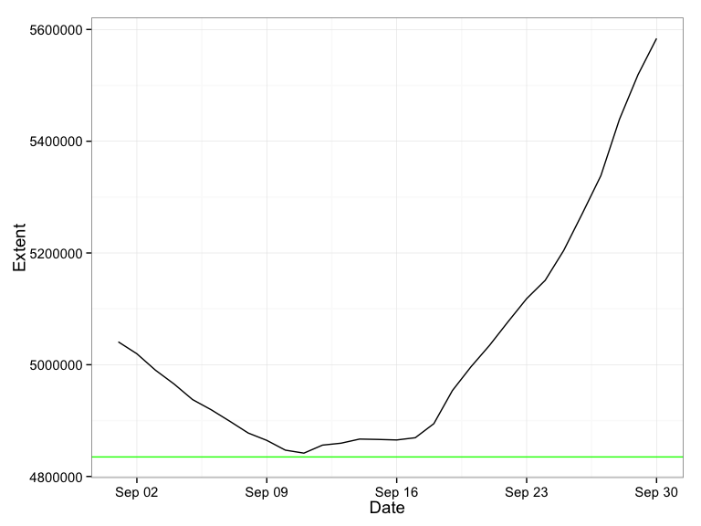

```r
mod.data %>% filter(Year == 2013, Month == 9) %>% ggplot(., aes(x = Date, y = Extent)) +
    theme_bw(14) + geom_line() + geom_hline(yintercept = sept2013, color = "green")
```

```r
comp.data <- read.csv("JAXA_Sea_Ice.csv") %>% melt(., id = c("Month", "Day"),
    variable.name = "Year", value.name = "Extent") %>% mutate(Year = as.numeric(substr(Year,
    2, 5)), Date = ymd(paste(Year, Month, Day, sep = "/")))
comp.data[which(comp.data$Extent == -9999), 4] <- NA

comp.data <- na.omit(comp.data)

test.mod <- mod.data %>% filter(Year == 2013, Month == 9)

test.comp <- comp.data %>% filter(Year == 2013, Month == 9)
```

There is some data funkiness about…

The blue line is from the arctic sea ice monitor site. The green line is from the long term data site. Same agency though…Probably different methods of calculating sea ice extent from the satellite data, they did mention that somewhere on their website…

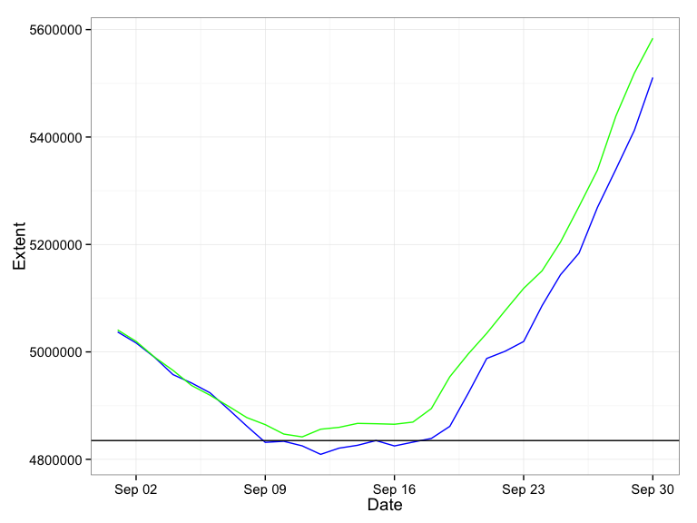

```r
ggplot() + geom_line(data = test.comp, aes(x = Date, y = Extent), color = "blue") +
    geom_line(data = test.mod, aes(x = Date, y = Extent), color = "green") +
    theme_bw(14) + geom_hline(yintercept = sept2013, color = "black")
```

Deseasoned time series (just trend and random components)

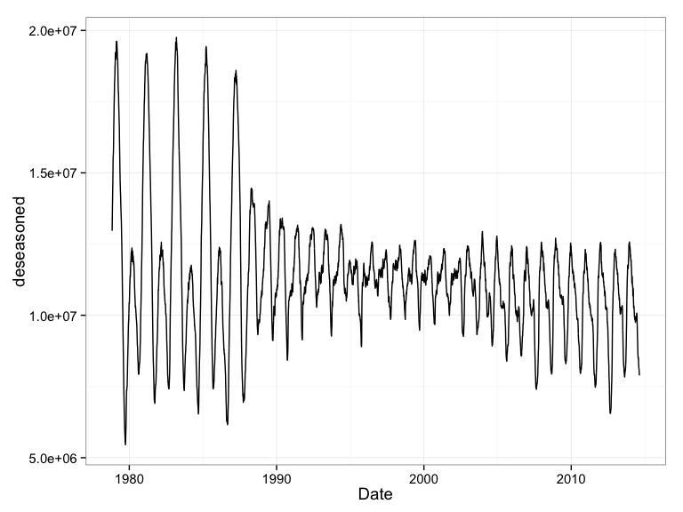

```r
p.ts %>% mutate(deseasoned = Extent - Seasonal) %>% ggplot(., aes(x = Date,
    y = deseasoned)) + geom_line() + theme_bw(14)
```